# 01-qPCR-test-plate

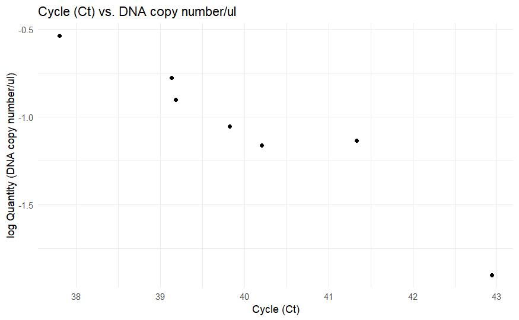

```r
slim_df %>%
  filter(Task != "STANDARD",
         CT != "Undetermined") %>%
  ggplot(aes(x = `Ct Mean`, y = log10(`Quantity Mean`))) +
  geom_point() +
  theme_minimal() +
  labs(title = "Cycle (Ct) vs. DNA copy number/ul",
       x = "Cycle (Ct)",
       y = "log Quantity (DNA copy number/ul)")
```

It bounces around a little bit, but maybe that’s just because we are looking at such a low threshold?

Look at by sample:

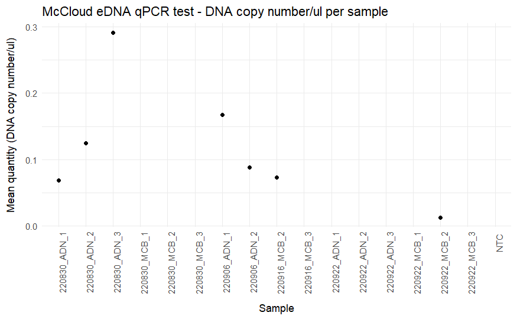

```r
slim_df %>%
  filter(Task != "STANDARD") %>%
  ggplot(aes(x = `Sample Name`, y = `Quantity Mean`)) +
  geom_point() +
  theme_minimal() +
  labs(title = "McCloud eDNA qPCR test - DNA copy number/ul per sample",
       x = "Sample",
       y = "Mean quantity (DNA copy number/ul)") +
  theme(
    axis.text.x = element_text(angle = 90, hjust = 0.95),
    axis.title.x = element_text(margin = margin(t = 10)),
    axis.title.y = element_text(margin = margin(r = 10)),
  )

ggsave("pdf_outputs/testplate_qPCR_mean_quantity.pdf", width = 6, height = 5)
```

Same plot, but with the IPC multiplexed:

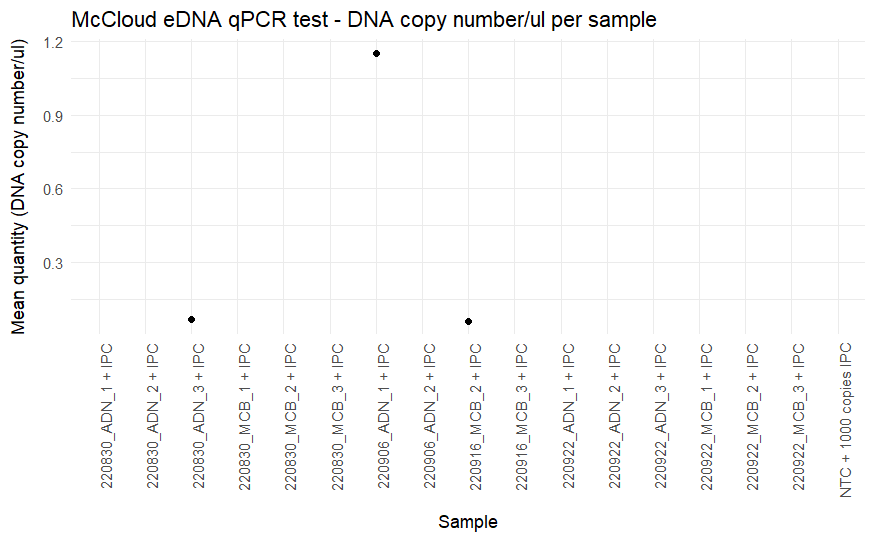

```r
test_data %>%
  filter(`Target Name` == "Target 1",
         str_detect(`Sample Name`, "IPC")) %>% # ignore all of the IPC standards
  select(`Sample Name`, Task, CT, `Ct Mean`, `Ct SD`, Quantity, `Quantity Mean`, `Quantity SD`) %>%
  filter(Task != "STANDARD") %>%
  ggplot(aes(x = `Sample Name`, y = `Quantity Mean`)) +
  geom_point() +
  theme_minimal() +
  labs(title = "McCloud eDNA qPCR test - DNA copy number/ul per sample",
       x = "Sample",
       y = "Mean quantity (DNA copy number/ul)") +
  theme(
    axis.text.x = element_text(angle = 90, hjust = 0.95),
    axis.title.x = element_text(margin = margin(t = 10)),
    axis.title.y = element_text(margin = margin(r = 10)),
  )
```

Way more drop-out. This could mean a) the multiplex is interfering or b) the concentration of the Chinook probe needs to be higher than the “probe mix” used in Ramon-Laca et al.

I’m still curious about inhibition - even though we’re seeing amplification. Seems like a good approach to dilute a handful of samples 1:10 and run them at both the original concentration and the dilute concentration to see if there’s a difference.